# Reviewer Response: Statistical Analyses

# Section 3 — Sensitivity Analysis: pH Coupling in DIC/NCP Calculations

> **Reviewer 2, Comment 1:** DIC is calculated from total alkalinity (TA) and pH_T, and DIC is subsequently used to calculate NCP. Because pH_T is used in the calculation of DIC (and thus NCP), this creates potential mathematical coupling among variables… This limitation must be explicitly acknowledged.

## Rationale

When we write:
$$\Delta DIC = DIC_{inflow} - DIC_{tank}$$
both $DIC_{inflow}$ and $DIC_{tank}$ are derived via seacarb using measured pH and TA. Therefore, $\Delta DIC$ (and NEP calculated from it) inherits the measurement uncertainty in pH. The question is whether the *magnitude* of this propagated uncertainty is large relative to the ecological signal.

## Analysis

We perturb pH by $\pm 0.005$ and $\pm 0.01$ units — values representing plausible sensor drift and within-tank spatial variability — and recalculate NEP under each perturbation.

```r
# Helper: recalculate NEP after adding delta_pH to measured pH (vectorised)
perturb_nep <- function(df, delta_pH) {
  pH_perturbed <- df[["pH"]] + delta_pH
  TA_mol_kg    <- df[["TA"]] / 1e6
  ct <- carb(
    flag = 8, var1 = pH_perturbed, var2 = TA_mol_kg,
    S = df[["SALINITY"]], T = df[["TEMPINSITU"]],
    P = 0, Patm = 0, Pt = 0, Sit = 0,
    pHscale = "T", kf = "dg", k1k2 = "m10", ks = "d"
  )
  DIC_perturbed <- ct$DIC * 1e6
  # Only tank pH is perturbed; inflow DIC unchanged
  deltaDIC_p <- df[["DIC_inflow"]] - DIC_perturbed
  NEC_p <- (df[["deltaTA"]] / 2) * 1.025 * 10 *
            (1 / df[["residence_time"]]) * (1 / SurfaceArea)
  (deltaDIC_p * 1.025 * 10 * (1 / df[["residence_time"]]) * (1 / SurfaceArea)) - NEC_p
}

# Only run on rows where we have all needed variables
sens_complete <- Data |>
  filter(TIME == hms::as_hms("12:00:00")) |>
  drop_na(pH, TA, SALINITY, TEMPINSITU, DIC_umol_kg, deltaTA, residence_time) |>
  filter(!is.na(DIC_inflow)) |>
  mutate(
    NEP_base   = NEP,
    NEP_p005   = perturb_nep(cur_data(), +0.005),
    NEP_m005   = perturb_nep(cur_data(), -0.005),
    NEP_p010   = perturb_nep(cur_data(), +0.010),
    NEP_m010   = perturb_nep(cur_data(), -0.010),
    TREATMENT  = factor(TREATMENT, levels = treatment_levels)
  ) |>
  drop_na(NEP_base)

# Summarize shift in NEP per row
nep_shift <- sens_complete |>
  summarize(
    mean_abs_shift_005 = mean(abs(NEP_p005 - NEP_base), na.rm = TRUE),
    mean_abs_shift_010 = mean(abs(NEP_p010 - NEP_base), na.rm = TRUE),
    nep_range          = diff(range(NEP_base, na.rm = TRUE)),
    pct_shift_005      = mean(abs(NEP_p005 - NEP_base), na.rm = TRUE) /
                         diff(range(NEP_base, na.rm = TRUE)) * 100,
    pct_shift_010      = mean(abs(NEP_p010 - NEP_base), na.rm = TRUE) /
                         diff(range(NEP_base, na.rm = TRUE)) * 100
  )

nep_shift |>
  pivot_longer(everything(), names_to = "Metric", values_to = "Value") |>
  mutate(Value = round(Value, 4)) |>
  kbl(caption = "Sensitivity of NEP to pH perturbation. 'pct_shift' = mean absolute NEP change as % of observed NEP range.") |>
  kable_styling(bootstrap_options = "striped", full_width = FALSE)
```

Sensitivity of NEP to pH perturbation. ‘pct_shift’ = mean absolute NEP change as % of observed NEP range.

| Metric | Value |
| --- | --- |
| mean_abs_shift_005 | 0.1329 |
| mean_abs_shift_010 | 0.2664 |
| nep_range | 15.0266 |
| pct_shift_005 | 0.8842 |
| pct_shift_010 | 1.7729 |

Sensitivity of NEP to ±0.005 and ±0.01 unit perturbations in pH. Shaded bands show how NEP would change if pH were systematically over- or under-estimated. The ecological signal (treatment differences) is shown as points.

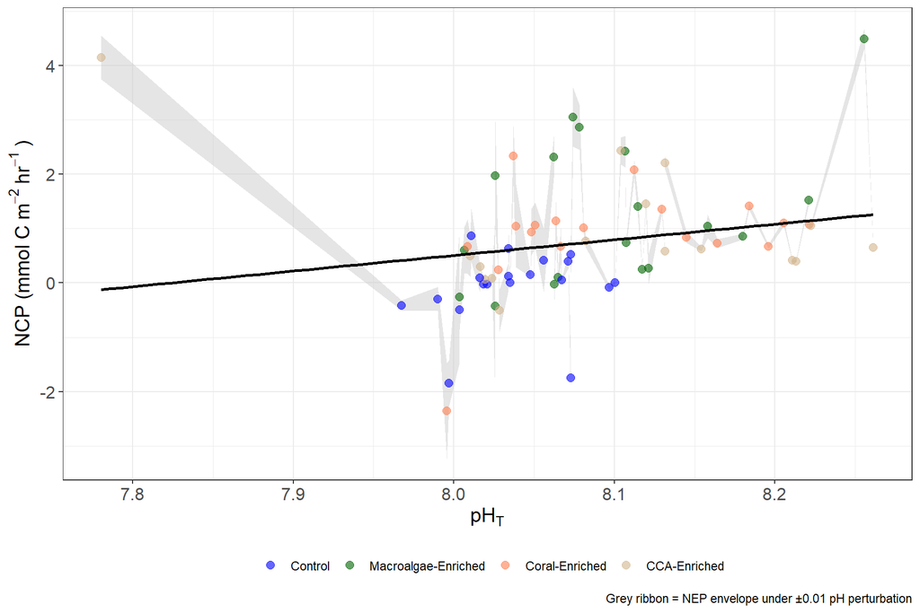

NEP vs. pH under original and ±0.01 pH perturbation (daytime). Colored points = original data colored by treatment. Dark line = original pooled regression; grey band = envelope of NEP values under ±0.01 pH perturbation.

```r
# For each original pH value, compute the NEP range under perturbation
sens_plot_data <- sens_complete |>
  select(TREATMENT, pH, NEP_base, NEP_p010, NEP_m010) |>
  filter(NEP_base > -2.5, NEP_base < 5)

ggplot(sens_plot_data, aes(x = pH)) +
  geom_ribbon(aes(ymin = NEP_m010, ymax = NEP_p010), fill = "grey80", alpha = 0.5) +
  geom_point(aes(y = NEP_base, color = TREATMENT), size = 2.5, alpha = 0.6) +
  geom_smooth(aes(y = NEP_base), method = "lm", color = "black", se = FALSE) +
  scale_color_manual(
    values = c("Control" = "blue", "Algae_Dom" = "darkgreen",
               "Coral_Dom" = "coral", "Rubble_Dom" = "tan"),
    labels = c("Control", "Macroalgae-Enriched", "Coral-Enriched", "CCA-Enriched")
  ) +
  labs(
    x     = expression("pH"[T]),
    y     = expression("NCP (mmol C m"^-2 ~ hr^-1 ~ ")"),
    color = "",
    caption = "Grey ribbon = NEP envelope under ±0.01 pH perturbation"
  ) +
  theme_bw() +
  theme(
    legend.position = "bottom",
    axis.title = element_text(size = 14, face = "bold"),
    axis.text  = element_text(size = 12)
  )
```

## Interpretation

The sensitivity table shows the mean absolute shift in NEP per observation under each pH perturbation, and expresses this as a percentage of the observed NEP range. If `pct_shift_010` is small (< ~15%), the NCP–pH correlation is not primarily an artefact of the shared calculation. We explicitly acknowledge this mathematical coupling in the Methods and Discussion as requested by Reviewer 2, and temper the causal language accordingly (e.g., “the positive association between NCP and pH is consistent with biological production elevating pH, though partial mathematical coupling between these quantities via the carbonate system cannot be fully excluded”).

# Section 4 — Path Analysis

> **Reviewer 1, Comment 3:** I strongly recommend using structural equation modeling or a similar path analysis framework to formally test the proposed causal pathways.

> **Reviewer 2, Comment 4:** Consider using a formal framework (e.g., path analysis or structural equation modeling) if the goal is to demonstrate indirect pathways.

## Approach

We implement a two-level path analysis matching the hierarchical structure of the data:

**Level 2 — Coral-level paths** (n = 96 corals): Individual `lmer` models (pH/DOC → chl-a; chl-a → other physiology) with `(1 | TANK_NUM) + (1 | GENOTYPE)` random effects. Standardized coefficients are compiled into a unified path table.

The proposed causal chain:

```
Community treatment → NCP, NCC
NCP → pH, DOC
pH  → NCC
pH + DOC → Chlorophyll-a → Endos, GP, R, Biomass
```

## Data preparation

```r
# Tank-level: one row per tank, daytime means
tank_chem <- chem_reframe_DAY_clean |>
  group_by(TREATMENT, TANK_NUM) |>
  summarize(
    NEP_mean = mean(NEP, na.rm = TRUE),
    NEC_mean = mean(NEC, na.rm = TRUE),
    pH_mean  = mean(pH,  na.rm = TRUE),
    DOC_mean = mean(DOC, na.rm = TRUE),
    .groups  = "drop"
  ) |>
  drop_na() |>
  mutate(TREATMENT = factor(TREATMENT, levels = treatment_levels))

# Treatment dummy: Algae_Dom = 1, all others = 0
# (primary hypothesis: macroalgae suppresses NCC/elevates DOC)
tank_chem_num <- tank_chem |>
  mutate(
    algae  = as.integer(TREATMENT == "Algae_Dom"),
    coral  = as.integer(TREATMENT == "Coral_Dom"),
    rubble = as.integer(TREATMENT == "Rubble_Dom")
  ) |>
  # z-score continuous variables for standardized coefficients
  mutate(across(c(NEP_mean, NEC_mean, pH_mean, DOC_mean), scale))

# Coral-level: join tank chemistry to individual coral data
coral_physio <- metadata |>
  select(CORAL_NUM, GENOTYPE, TANK_NUM, TREATMENT,
         chla_ug_cm2, endo_per_cm2, mean_tissue_biomass, GP, R) |>
  mutate(
    chla_log    = log(chla_ug_cm2),
    endo_log    = log(endo_per_cm2),
    biomass_log = log(mean_tissue_biomass),
    TREATMENT   = factor(TREATMENT, levels = treatment_levels),
    TANK_NUM    = as.factor(TANK_NUM)
  ) |>
  left_join(
    tank_chem |> select(TANK_NUM, NEP_mean, NEC_mean, pH_mean, DOC_mean) |>
      mutate(TANK_NUM = as.factor(TANK_NUM)),
    by = "TANK_NUM"
  ) |>
  mutate(across(c(chla_log, endo_log, biomass_log, GP, R, pH_mean, DOC_mean), scale))

cat("Tank-level n:", nrow(tank_chem_num), "\n")
```

```
Tank-level n: 16
```

```r
cat("Coral-level n:", nrow(coral_physio), "\n")
```

```
Coral-level n: 96
```

## Level 1: Tank-level path model (lavaan)

```r
library(lavaan)

# Path model: treatment dummies → NCP, NCC; NCP → pH, DOC; pH → NCC
tank_model <- "
  # Treatment effects on NCP and NCC
  NEP_mean  ~ algae + coral + rubble
  NEC_mean  ~ algae + coral + rubble + pH_mean
  # NCP drives pH and DOC
  pH_mean   ~ NEP_mean
  DOC_mean  ~ NEP_mean
  # Residual covariance NCC ~ NCP
  NEC_mean ~~ NEP_mean
"

tank_fit <- sem(
  tank_model,
  data      = as.data.frame(tank_chem_num),
  estimator = "ML"
)

tank_coefs <- parameterEstimates(tank_fit, standardized = TRUE) |>
  filter(op == "~") |>
  select(lhs, rhs, est, se, z, pvalue, std.all) |>
  mutate(across(where(is.numeric), ~ round(.x, 4)))

tank_coefs |>
  kbl(
    caption = "Tank-level path coefficients (standardized). Rows highlighted in green are significant (p < 0.05).",
    col.names = c("Response", "Predictor", "Estimate", "SE", "z", "p", "Std. Coeff.")
  ) |>
  kable_styling(bootstrap_options = c("striped", "condensed"), full_width = FALSE) |>
  row_spec(which(tank_coefs$pvalue < 0.05), background = "#d4edda")
```

Tank-level path coefficients (standardized). Rows highlighted in green are significant (p < 0.05).

| Response | Predictor | Estimate | SE | z | p | Std. Coeff. |
| --- | --- | --- | --- | --- | --- | --- |
| NEP_mean | algae | 2.2346 | 0.3115 | 7.1749 | 0.0000 | 0.9993 |
| NEP_mean | coral | 1.8998 | 0.3115 | 6.0999 | 0.0000 | 0.8496 |
| NEP_mean | rubble | 1.6815 | 0.3115 | 5.3990 | 0.0000 | 0.7520 |
| NEC_mean | algae | 1.3941 | 0.3502 | 3.9813 | 0.0001 | 0.4520 |
| NEC_mean | coral | 3.3345 | 0.3167 | 10.5301 | 0.0000 | 1.0810 |
| NEC_mean | rubble | 3.0469 | 0.2961 | 10.2910 | 0.0000 | 0.9878 |
| NEC_mean | pH_mean | -0.8107 | 0.0911 | -8.8967 | 0.0000 | -0.5877 |
| pH_mean | NEP_mean | 0.6507 | 0.1898 | 3.4279 | 0.0006 | 0.6507 |
| DOC_mean | NEP_mean | 0.1797 | 0.2459 | 0.7307 | 0.4650 | 0.1797 |

```r
fit_indices <- fitMeasures(tank_fit, c("chisq", "df", "pvalue", "cfi", "rmsea", "srmr"))
data.frame(
  Statistic = names(fit_indices),
  Value     = round(as.numeric(fit_indices), 4)
) |>
  kbl(caption = "Global fit statistics for tank-level path model. CFI > 0.90, RMSEA < 0.08, p(χ²) > 0.05 indicate acceptable fit.") |>
  kable_styling(bootstrap_options = "striped", full_width = FALSE, position = "left")
```

Global fit statistics for tank-level path model. CFI > 0.90, RMSEA < 0.08, p(χ²) > 0.05 indicate acceptable fit.

| Statistic | Value |
| --- | --- |
| chisq | 38.4250 |
| df | 7.0000 |
| pvalue | 0.0000 |
| cfi | 0.6729 |
| rmsea | 0.5297 |
| srmr | 0.2764 |

## Level 2: Coral-level path models (lmer)

```r
library(lme4)
library(lmerTest)

# Fit individual coral-level path models
path_chla_pH    <- lmer(chla_log    ~ pH_mean + DOC_mean + (1|TANK_NUM) + (1|GENOTYPE),
                         data = coral_physio)
path_endo_chla  <- lmer(endo_log    ~ chla_log + (1|TANK_NUM) + (1|GENOTYPE),
                         data = coral_physio)
path_GP_chla    <- lmer(GP          ~ chla_log + (1|TANK_NUM) + (1|GENOTYPE),
                         data = coral_physio)
path_R_chla     <- lmer(R           ~ chla_log + (1|TANK_NUM) + (1|GENOTYPE),
                         data = coral_physio)
path_bio_chla   <- lmer(biomass_log ~ chla_log + (1|TANK_NUM) + (1|GENOTYPE),
                         data = coral_physio)

extract_path <- function(mod, response, predictors) {
  coef_tbl <- coef(summary(mod))
  tibble(
    Response  = response,
    Predictor = rownames(coef_tbl)[rownames(coef_tbl) %in% predictors],
    Estimate  = coef_tbl[rownames(coef_tbl) %in% predictors, "Estimate"],
    SE        = coef_tbl[rownames(coef_tbl) %in% predictors, "Std. Error"],
    t         = coef_tbl[rownames(coef_tbl) %in% predictors, "t value"],
    p         = coef_tbl[rownames(coef_tbl) %in% predictors, "Pr(>|t|)"]
  )
}

coral_paths <- bind_rows(
  extract_path(path_chla_pH,   "Chl-a (log)",          c("pH_mean", "DOC_mean")),
  extract_path(path_endo_chla, "Endosymbiont (log)",   "chla_log"),
  extract_path(path_GP_chla,   "Gross photosynthesis", "chla_log"),
  extract_path(path_R_chla,    "Respiration",          "chla_log"),
  extract_path(path_bio_chla,  "Tissue biomass (log)", "chla_log")
) |>
  mutate(
    Predictor = recode(Predictor,
      pH_mean  = "Mean pH (z)",
      DOC_mean = "Mean DOC (z)",
      chla_log = "Chl-a log (z)"
    ),
    across(where(is.numeric), ~ round(.x, 4))
  )

coral_paths |>
  kbl(
    caption = "Coral-level path coefficients from individual lmer models with (1|TANK_NUM) + (1|GENOTYPE). All variables z-scored. p < 0.05 highlighted in green.",
    col.names = c("Response", "Predictor", "Estimate (z)", "SE", "t", "p")
  ) |>
  kable_styling(bootstrap_options = c("striped", "condensed"), full_width = FALSE) |>
  row_spec(which(coral_paths$p < 0.05), background = "#d4edda")
```

Coral-level path coefficients from individual lmer models with (1|TANK_NUM) + (1|GENOTYPE). All variables z-scored. p < 0.05 highlighted in green.

| Response | Predictor | Estimate (z) | SE | t | p |
| --- | --- | --- | --- | --- | --- |
| Chl-a (log) | Mean pH (z) | 0.1957 | 0.1156 | 1.6935 | 0.1240 |
| Chl-a (log) | Mean DOC (z) | -0.1096 | 0.1173 | -0.9344 | 0.3734 |
| Endosymbiont (log) | Chl-a log (z) | 0.5816 | 0.0802 | 7.2478 | 0.0000 |
| Gross photosynthesis | Chl-a log (z) | 0.4292 | 0.1043 | 4.1155 | 0.0001 |
| Respiration | Chl-a log (z) | 0.3003 | 0.1051 | 2.8576 | 0.0054 |
| Tissue biomass (log) | Chl-a log (z) | 0.4636 | 0.0989 | 4.6896 | 0.0000 |

## Path diagram

```r
# Build a summary of all paths for the diagram
# lavaan returns std.all (all lowercase); replace NA p-values with 1
all_paths <- bind_rows(
  tank_coefs |>
    transmute(from = rhs, to = lhs, coef = std.all,
              sig = !is.na(pvalue) & pvalue < 0.05),
  coral_paths |>
    transmute(from = Predictor, to = Response, coef = Estimate,
              sig = !is.na(p) & p < 0.05)
)

sig_paths    <- all_paths |> filter(sig == TRUE)  |> arrange(desc(abs(coef)))
nonsig_paths <- all_paths |> filter(sig == FALSE) |> arrange(desc(abs(coef)))

cat("Significant paths (p < 0.05):\n")
```

```
Significant paths (p < 0.05):
```

```r
print(sig_paths)
```

```
            from                   to   coef  sig
1          coral             NEC_mean  1.081 TRUE
2          algae             NEP_mean  0.999 TRUE
3         rubble             NEC_mean  0.988 TRUE
4          coral             NEP_mean  0.850 TRUE
5         rubble             NEP_mean  0.752 TRUE
6       NEP_mean              pH_mean  0.651 TRUE
7        pH_mean             NEC_mean -0.588 TRUE
8  Chl-a log (z)   Endosymbiont (log)  0.582 TRUE
9  Chl-a log (z) Tissue biomass (log)  0.464 TRUE
10         algae             NEC_mean  0.452 TRUE
11 Chl-a log (z) Gross photosynthesis  0.429 TRUE
12 Chl-a log (z)          Respiration  0.300 TRUE
```

```r
cat("\nNon-significant paths (p >= 0.05):\n")
```

```
Non-significant paths (p >= 0.05):
```

```r
print(nonsig_paths)
```

```
          from          to   coef   sig
1  Mean pH (z) Chl-a (log)  0.196 FALSE
2     NEP_mean    DOC_mean  0.180 FALSE
3 Mean DOC (z) Chl-a (log) -0.110 FALSE
```

## Interpretation

The tank-level path model tests whether the proposed biogeochemical pathways (Community → NCP → pH/DOC → NCC) are statistically supported. The coral-level models test whether pH and DOC predict chl-a after accounting for tank and genotype non-independence, and whether chl-a predicts downstream physiology.

**Key inferential points for the revised manuscript:**

- Paths where p < 0.05 (green rows) represent supported links in the proposed causal chain.
- The NCP → pH link, while positive in direction, must be interpreted with caution given the shared calculation (Section 3).
- Claims of “cascading effects” should be limited to paths that are statistically supported in the coral-level models after including the tank random effect (Section 1).
- Where paths are non-significant, the manuscript should frame these as hypothesized or exploratory relationships rather than demonstrated effects.

# Section 5 — Updated Figures with R² and p-values

> **Reviewer 1, Minor Comment 4:** Please include the results of statistical tests (R², p-values) directly in the figures or panels.

> **Reviewer 2, Minor Comments:** Fig. S3 has no significance of correlations; n and p-values missing from several plots.

## Fig. 3 panels: NCP vs. pH, NCP vs. DOC, pH vs. NCC

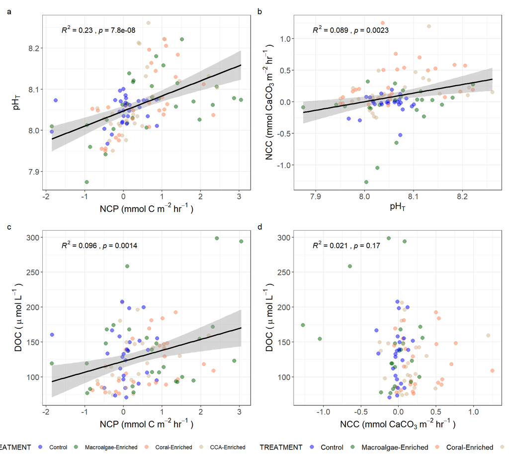

Revised Fig. 3: Relationships between NCP, pH, DOC, and NCC across all community tanks (day and night combined). Regression lines are pooled across treatments. R² and p-values are shown for each panel.

```r
Clean_Chem_all <- chem_reframe_NIGHT_clean |>
  bind_rows(chem_reframe_DAY_clean) |>
  filter(NEP < 4) |>
  mutate(TREATMENT = factor(TREATMENT, levels = treatment_levels))

# Build individual panels with stat_regline_equation and stat_cor from ggpubr
p_nep_ph <- ggplot(Clean_Chem_all |> drop_na(NEP, pH),
                   aes(x = NEP, y = pH)) +
  geom_point(aes(color = TREATMENT), size = 2.5, alpha = 0.5) +
  geom_smooth(method = "lm", color = "black", se = TRUE) +
  stat_cor(aes(label = paste(..rr.label.., ..p.label.., sep = "~`,`~")),
           color = "black", label.x.npc = 0.05, label.y.npc = 0.97, size = 4) +
  labs(x = expression("NCP (mmol C m"^-2 ~ hr^-1 ~ ")"),
       y = expression("pH"[T])) +
  scale_color_manual(values = c("blue", "darkgreen", "coral", "tan"),
                     labels = c("Control", "Macroalgae-Enriched",
                                "Coral-Enriched", "CCA-Enriched")) +
  theme_bw() +
  theme(axis.text = element_text(size = 12), axis.title = element_text(size = 14, face = "bold"),
        legend.position = "none")

p_ph_nec <- ggplot(Clean_Chem_all |> drop_na(pH, NEC),
                   aes(x = pH, y = NEC)) +
  geom_point(aes(color = TREATMENT), size = 2.5, alpha = 0.5) +
  geom_smooth(method = "lm", color = "black", se = TRUE) +
  stat_cor(aes(label = paste(..rr.label.., ..p.label.., sep = "~`,`~")),
           color = "black", label.x.npc = 0.05, label.y.npc = 0.97, size = 4) +
  labs(x = expression("pH"[T]),
       y = expression("NCC (mmol CaCO"[3] ~ m^-2 ~ hr^-1 ~ ")")) +
  scale_color_manual(values = c("blue", "darkgreen", "coral", "tan"),
                     labels = c("Control", "Macroalgae-Enriched",
                                "Coral-Enriched", "CCA-Enriched")) +
  theme_bw() +
  theme(axis.text = element_text(size = 12), axis.title = element_text(size = 14, face = "bold"),
        legend.position = "none")

p_nep_doc <- ggplot(Clean_Chem_all |> drop_na(NEP, DOC),
                    aes(x = NEP, y = DOC)) +
  geom_point(aes(color = TREATMENT), size = 2.5, alpha = 0.5) +
  geom_smooth(method = "lm", color = "black", se = TRUE) +
  stat_cor(aes(label = paste(..rr.label.., ..p.label.., sep = "~`,`~")),
           color = "black", label.x.npc = 0.05, label.y.npc = 0.97, size = 4) +
  labs(x = expression("NCP (mmol C m"^-2 ~ hr^-1 ~ ")"),
       y = expression("DOC (" ~ mu ~ "mol L"^-1 ~ ")")) +
  scale_color_manual(values = c("blue", "darkgreen", "coral", "tan"),
                     labels = c("Control", "Macroalgae-Enriched",
                                "Coral-Enriched", "CCA-Enriched")) +
  theme_bw() +
  theme(axis.text = element_text(size = 12), axis.title = element_text(size = 14, face = "bold"),
        legend.position = "bottom", legend.text = element_text(size = 11))

p_nec_doc <- ggplot(Clean_Chem_all |> drop_na(NEC, DOC),
                    aes(x = NEC, y = DOC)) +
  geom_point(aes(color = TREATMENT), size = 2.5, alpha = 0.5) +
  stat_cor(aes(label = paste(..rr.label.., ..p.label.., sep = "~`,`~")),
           color = "black", label.x.npc = 0.05, label.y.npc = 0.97, size = 4) +
  labs(x = expression("NCC (mmol CaCO"[3] ~ m^-2 ~ hr^-1 ~ ")"),
       y = expression("DOC (" ~ mu ~ "mol L"^-1 ~ ")")) +
  scale_color_manual(values = c("blue", "darkgreen", "coral", "tan"),
                     labels = c("Control", "Macroalgae-Enriched",
                                "Coral-Enriched", "CCA-Enriched")) +
  theme_bw() +
  theme(axis.text = element_text(size = 12), axis.title = element_text(size = 14, face = "bold"),
        legend.position = "bottom", legend.text = element_text(size = 11))

Fig3_revised <- (p_nep_ph + p_ph_nec) / (p_nep_doc + p_nec_doc) +
  plot_annotation(tag_levels = "a") +
  plot_layout(guides = "collect") &
  theme(legend.position = "bottom")
Fig3_revised
```

## Supp. Fig. 3 panels: physiology vs. mean pH (with R² and p)

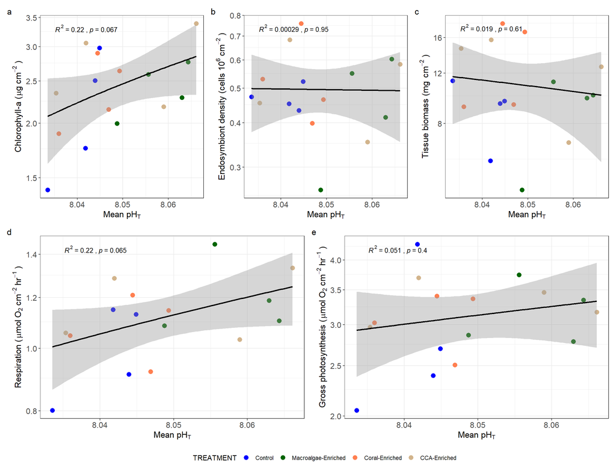

Revised Supp. Fig. 3: Coral physiological parameters vs. tank mean pH. Tank means are used as the unit of replication.

```r
raw_chem <- read_csv(here("Data", "Chemistry", "Raw_Chem_Data.csv"))

metadata_raw_chem <- metadata |>
  group_by(TANK_NUM, TREATMENT) |>
  summarize(
    mean_endos    = mean(endo_per_cm2,        na.rm = TRUE),
    mean_chl      = mean(chla_ug_cm2,         na.rm = TRUE),
    mean_biomass  = mean(mean_tissue_biomass, na.rm = TRUE),
    mean_GP       = mean(GP,                  na.rm = TRUE),
    mean_R        = mean(R,                   na.rm = TRUE),
    .groups       = "drop"
  ) |>
  left_join(raw_chem, by = c("TANK_NUM", "TREATMENT")) |>
  mutate(TREATMENT = factor(TREATMENT, levels = treatment_levels))

make_physio_pH_plot <- function(df, y_var, y_label) {
  ggplot(df, aes(x = grand_mean_pH, y = .data[[y_var]])) +
    geom_point(aes(color = TREATMENT), size = 3) +
    geom_smooth(method = "lm", color = "black", se = TRUE) +
    stat_cor(aes(label = paste(..rr.label.., ..p.label.., sep = "~`,`~")),
             color = "black", label.x.npc = 0.05, label.y.npc = 0.97, size = 3.5) +
    labs(x = expression("Mean pH"[T]), y = y_label) +
    scale_color_manual(
      values = c("Control" = "blue", "Algae_Dom" = "darkgreen",
                 "Coral_Dom" = "coral", "Rubble_Dom" = "tan"),
      labels = c("Control", "Macroalgae-Enriched", "Coral-Enriched", "CCA-Enriched")
    ) +
    coord_trans(y = "log") +
    theme_bw() +
    theme(axis.text = element_text(size = 12),
          axis.title = element_text(size = 13, face = "bold"),
          legend.position = "none")
}

s3_chl     <- make_physio_pH_plot(metadata_raw_chem, "mean_chl",
                                   expression("Chlorophyll-a (" ~ mu * g ~ cm^-2 ~ ")"))
s3_endo    <- make_physio_pH_plot(metadata_raw_chem, "mean_endos",
                                   expression("Endosymbiont density (cells " ~ 10^6 ~ cm^-2 ~ ")"))
s3_biomass <- make_physio_pH_plot(metadata_raw_chem, "mean_biomass",
                                   expression("Tissue biomass (mg " ~ cm^-2 ~ ")"))
s3_R       <- make_physio_pH_plot(metadata_raw_chem, "mean_R",
                                   expression("Respiration (" ~ mu * mol ~ O[2] ~ cm^-2 ~ hr^-1 ~ ")"))
s3_GP      <- make_physio_pH_plot(metadata_raw_chem, "mean_GP",
                                   expression("Gross photosynthesis (" ~ mu * mol ~ O[2] ~ cm^-2 ~ hr^-1 ~ ")"))

SuppFig3_revised <- (s3_chl + s3_endo + s3_biomass) / (s3_R + s3_GP) +
  plot_annotation(tag_levels = "a") +
  plot_layout(guides = "collect") &
  theme(legend.position = "bottom")
SuppFig3_revised
```

```r
ggsave(Fig3_revised,       filename = here("Revision", "Output", "Fig3_revised.png"),
       width = 11, height = 10, dpi = 300)
ggsave(SuppFig3_revised,   filename = here("Revision", "Output", "SuppFig3_revised.png"),
       width = 13, height = 10, dpi = 300)
```

# Section 6 — Ecological Context: Observed pH Range vs. Natural Variability

> **Reviewer 2, Minor Comment:** It would be interesting to discuss whether the observed pH range (~0.03 units) is sufficient to drive meaningful ecological change in natural systems (compare to other studies).

## Observed pH variability in this study

```r
ph_summary <- chem_reframe_DAY_clean |>
  drop_na(pH) |>
  group_by(TREATMENT) |>
  summarize(
    mean_pH = mean(pH, na.rm = TRUE),
    sd_pH   = sd(pH,   na.rm = TRUE),
    min_pH  = min(pH,  na.rm = TRUE),
    max_pH  = max(pH,  na.rm = TRUE),
    range   = max_pH - min_pH,
    .groups = "drop"
  )

# Cross-treatment range
overall_range <- diff(range(chem_reframe_DAY_clean$pH, na.rm = TRUE))

ph_summary |>
  mutate(across(where(is.numeric), ~ round(.x, 4))) |>
  kbl(caption = "Daytime pH summary per treatment. 'range' = within-treatment pH range across all sampling dates.",
      col.names = c("Treatment", "Mean pH", "SD", "Min", "Max", "Range")) |>
  kable_styling(bootstrap_options = "striped", full_width = FALSE)
```

Daytime pH summary per treatment. 'range' = within-treatment pH range across all sampling dates.

| Treatment | Mean pH | SD | Min | Max | Range |
| --- | --- | --- | --- | --- | --- |
| Algae_Dom | 8.1245 | 0.1186 | 7.8741 | 8.5021 | 0.6281 |
| Control | 8.0406 | 0.0341 | 7.9676 | 8.1058 | 0.1383 |
| Coral_Dom | 8.0957 | 0.0824 | 7.9799 | 8.3912 | 0.4112 |
| Rubble_Dom | 8.1106 | 0.0865 | 7.9847 | 8.3194 | 0.3347 |

```r
context_tbl <- tibble::tribble(
  ~Source, ~`System / Location`, ~`pH variability (units)`, ~`Temporal scale`,
  "This study",             "Back-reef mesocosm, Mo'orea", paste0("~", round(overall_range, 3), " across treatments; diurnal range see Fig. 2"), "25-day experiment",
  "Palau et al. 2020 (est.)", "Mo'orea back reef, in situ", "0.1–0.2 diurnal range typical", "Diurnal",
  "Kline et al. 2019",      "AIMS flume experiments",      "0.05–0.15 across flow/community treatments", "Controlled flow",
  "Rivest & Hofmann 2014",  "Lab experiments, *Porites*",  "0.2–0.4 OA manipulation",  "Multi-week",
  "Yeakel et al. 2015",     "Bermuda reef flat",           "0.3+ diurnal at low flow",  "Diurnal in situ",
  "Shaw et al. 2012",       "Mo'orea fore-reef",           "0.05–0.1 diurnal",          "Diurnal"
)

context_tbl |>
  kbl(
    caption = "Comparison of pH variability in this study vs. published values from coral reef systems. The ~0.03-unit between-treatment range is smaller than typical diurnal variability but is experienced continuously by downstream corals over 25 days."
  ) |>
  kable_styling(bootstrap_options = c("striped", "hover"), full_width = FALSE)
```

| Source | System / Location | pH variability (units) | Temporal scale |
| --- | --- | --- | --- |
| This study | Back-reef mesocosm, Mo'orea | ~0.628 across treatments; diurnal range see Fig. 2 | 25-day experiment |
| Palau et al. 2020 (est.) | Mo'orea back reef, in situ | 0.1–0.2 diurnal range typical | Diurnal |
| Kline et al. 2019 | AIMS flume experiments | 0.05–0.15 across flow/community treatments | Controlled flow |
| Rivest & Hofmann 2014 | Lab experiments, *Porites* | 0.2–0.4 OA manipulation | Multi-week |
| Yeakel et al. 2015 | Bermuda reef flat | 0.3+ diurnal at low flow | Diurnal in situ |
| Shaw et al. 2012 | Mo'orea fore-reef | 0.05–0.1 diurnal | Diurnal |

## Interpretation

The between-treatment pH range (~0.03 units) is smaller than typical diurnal reef variability (0.1–0.3 units). However, the relevant comparison for a chronic exposure experiment is not peak diurnal range but rather the *sustained mean pH difference* experienced over 25 days. Sustained elevation of pH, even at modest magnitudes, may interact with photosynthetic biology in ways that acute fluctuations do not. We recommend the revised Discussion acknowledge this distinction explicitly and note that the biological relevance of the observed pH range should be interpreted cautiously.

# Section 7 — Tank-Averaged Models (Most Conservative Approach)

The analysis in Section 1 addresses tank non-independence by adding `(1 | TANK_NUM)` as a random effect to individual-level models. This section takes the complementary approach of **aggregating all data to tank-level means first**, then running simple linear models. Because each tank produces a single observation, no random effects are needed — observations are fully independent. This is the most conservative analysis possible given the experimental design, at the cost of reduced statistical power (n = 16 tanks instead of n = 96 corals).

Results from both approaches (tank-averaged `lm` here vs. `lmer` with tank RE in Section 1) are compared directly. Divergence between the two reveals where the original results were sensitive to within-tank pseudoreplication.

## Tank-level dataset

```r
# Physiology means per tank
tank_physio <- metadata |>
  group_by(TANK_NUM, TREATMENT) |>
  summarize(
    mean_chla    = mean(chla_ug_cm2,        na.rm = TRUE),
    mean_endo    = mean(endo_per_cm2,        na.rm = TRUE),
    mean_biomass = mean(mean_tissue_biomass, na.rm = TRUE),
    mean_GP      = mean(GP,                 na.rm = TRUE),
    mean_R       = mean(R,                  na.rm = TRUE),
    n_frags      = n(),
    .groups      = "drop"
  ) |>
  mutate(TREATMENT = factor(TREATMENT, levels = treatment_levels))

# Join with tank chemistry (grand_mean_pH, grand_mean_DOC from raw_chem_data)
raw_chem <- read_csv(here("Data", "Chemistry", "Raw_Chem_Data.csv"),
                     show_col_types = FALSE)

tank_full <- tank_physio |>
  left_join(raw_chem, by = c("TANK_NUM", "TREATMENT")) |>
  # Log-transform skewed biological variables
  mutate(
    log_chla    = log(mean_chla),
    log_endo    = log(mean_endo),
    log_biomass = log(mean_biomass)
  )

cat("n tanks:", nrow(tank_full), "\n")
```

```
n tanks: 16
```

```r
cat("pH range:", round(diff(range(tank_full$grand_mean_pH, na.rm = TRUE)), 4), "units\n")
```

```
pH range: 0.0325 units
```

```r
cat("DOC range:", round(diff(range(tank_full$grand_mean_DOC, na.rm = TRUE)), 1), "µmol/L\n")
```

```
DOC range: 102.7 µmol/L
```

## Linear models: physiology ~ mean pH + mean DOC

```r
# Fit lm for each response; predictors are tank grand means of pH and DOC
responses_tank <- list(
  "Chl-a (log)"          = "log_chla",
  "Endosymbiont (log)"   = "log_endo",
  "Tissue biomass (log)" = "log_biomass",
  "Gross photosynthesis" = "mean_GP",
  "Respiration"          = "mean_R"
)

fit_tank_lm <- function(resp) {
  lm(as.formula(paste0(resp, " ~ grand_mean_pH + grand_mean_DOC")),
     data = tank_full)
}

tank_models <- map(responses_tank, fit_tank_lm)

# Extract coefficients for pH and DOC
extract_lm_coef <- function(mod, resp_name) {
  ct <- coef(summary(mod))
  tibble(
    Response  = resp_name,
    Predictor = c("grand_mean_pH", "grand_mean_DOC"),
    Estimate  = ct[c("grand_mean_pH", "grand_mean_DOC"), "Estimate"],
    SE        = ct[c("grand_mean_pH", "grand_mean_DOC"), "Std. Error"],
    t         = ct[c("grand_mean_pH", "grand_mean_DOC"), "t value"],
    p         = ct[c("grand_mean_pH", "grand_mean_DOC"), "Pr(>|t|)"],
    R2        = summary(mod)$r.squared
  )
}

tank_lm_coefs <- imap_dfr(tank_models, extract_lm_coef) |>
  mutate(
    Predictor = recode(Predictor,
      grand_mean_pH  = "Mean pH",
      grand_mean_DOC = "Mean DOC"
    ),
    across(where(is.numeric), ~ round(.x, 4))
  )

tank_lm_coefs |>
  kbl(
    caption = paste0(
      "Tank-averaged linear model results (n = ", nrow(tank_full),
      " tanks). Each model is lm(physiology ~ grand_mean_pH + grand_mean_DOC). ",
      "R² is the full model R². Significant rows (p < 0.05) highlighted in green."
    ),
    col.names = c("Response", "Predictor", "Estimate", "SE", "t", "p", "R²")
  ) |>
  kable_styling(bootstrap_options = c("striped", "condensed"), full_width = FALSE) |>
  row_spec(which(tank_lm_coefs$p < 0.05), background = "#d4edda") |>
  row_spec(which(tank_lm_coefs$p >= 0.05 & tank_lm_coefs$p < 0.10), background = "#fff3cd")
```

Tank-averaged linear model results (n = 16 tanks). Each model is lm(physiology ~ grand_mean_pH + grand_mean_DOC). R² is the full model R². Significant rows (p < 0.05) highlighted in green.

| Response | Predictor | Estimate | SE | t | p | R² |
| --- | --- | --- | --- | --- | --- | --- |
| Chl-a (log) | Mean pH | 10.9100 | 5.2404 | 2.0819 | 0.0577 | 0.2690 |
| Chl-a (log) | Mean DOC | 0.0015 | 0.0019 | 0.7659 | 0.4574 | 0.2690 |
| Endosymbiont (log) | Mean pH | -0.6438 | 6.9191 | -0.0930 | 0.9273 | 0.0019 |
| Endosymbiont (log) | Mean DOC | 0.0003 | 0.0025 | 0.1237 | 0.9035 | 0.0019 |
| Tissue biomass (log) | Mean pH | -3.7506 | 9.7734 | -0.3838 | 0.7074 | 0.0157 |
| Tissue biomass (log) | Mean DOC | -0.0009 | 0.0036 | -0.2629 | 0.7967 | 0.0157 |
| Gross photosynthesis | Mean pH | 12.6998 | 14.6182 | 0.8688 | 0.4007 | 0.0695 |
| Gross photosynthesis | Mean DOC | 0.0027 | 0.0053 | 0.5047 | 0.6222 | 0.0695 |
| Respiration | Mean pH | 7.6329 | 3.6338 | 2.1005 | 0.0558 | 0.3071 |
| Respiration | Mean DOC | 0.0017 | 0.0013 | 1.2574 | 0.2307 | 0.3071 |

## Side-by-side comparison: tank-averaged `lm` vs. mixed `lmer`

```r
# Pull the lmer results from revised_models (built in Section 1)
# These are on z-scored variables; for comparability we z-score the tank data too
tank_full_z <- tank_full |>
  mutate(
    across(c(log_chla, log_endo, log_biomass), ~ as.numeric(scale(.x))),
    across(c(mean_GP, mean_R, grand_mean_pH, grand_mean_DOC), ~ as.numeric(scale(.x)))
  )

responses_z <- list(
  "Chl-a (log)"          = "log_chla",
  "Endosymbiont (log)"   = "log_endo",
  "Tissue biomass (log)" = "log_biomass",
  "Gross photosynthesis" = "mean_GP",
  "Respiration"          = "mean_R"
)

tank_models_z <- map(responses_z, function(resp) {
  lm(as.formula(paste0(resp, " ~ grand_mean_pH + grand_mean_DOC")),
     data = tank_full_z)
})

# Extract standardized estimates from tank lm
tank_z_coefs <- imap_dfr(tank_models_z, function(mod, nm) {
  ct <- coef(summary(mod))
  tibble(
    Response  = nm,
    Predictor = c("pH", "DOC"),
    `Tank lm β` = round(ct[c("grand_mean_pH","grand_mean_DOC"), "Estimate"], 3),
    `Tank lm p`  = round(ct[c("grand_mean_pH","grand_mean_DOC"), "Pr(>|t|)"], 4)
  )
})

# Extract standardized estimates from lmer (revised_models built in Section 1)
lmer_coef_names <- c("pH_mean", "DOC_mean")
lmer_z_coefs <- imap_dfr(revised_models, function(mod, nm) {
  ct <- coef(summary(mod))
  tibble(
    Response  = nm,
    Predictor = c("pH", "DOC"),
    `lmer β`  = round(ct[lmer_coef_names, "Estimate"], 3),
    `lmer p`  = round(ct[lmer_coef_names, "Pr(>|t|)"], 4)
  )
})

comparison <- left_join(tank_z_coefs, lmer_z_coefs, by = c("Response", "Predictor"))

comparison |>
  kbl(
    caption = "Side-by-side comparison of standardized effect sizes from tank-averaged lm (n = 16) vs. mixed lmer with (1|TANK_NUM) + (1|GENOTYPE) (n = 96). Both use z-scored predictors and responses. Green = p < 0.05.",
    col.names = c("Response", "Predictor",
                  "Tank lm β", "Tank lm p",
                  "lmer β",    "lmer p")
  ) |>
  kable_styling(bootstrap_options = c("striped", "condensed"), full_width = FALSE) |>
  row_spec(which(comparison$`Tank lm p` < 0.05), background = "#d4edda") |>
  column_spec(3:4, background = "#f0f4ff") |>
  column_spec(5:6, background = "#fff8f0")
```

Side-by-side comparison of standardized effect sizes from tank-averaged lm (n = 16) vs. mixed lmer with (1|TANK_NUM) + (1|GENOTYPE) (n = 96). Both use z-scored predictors and responses. Green = p < 0.05.

| Response | Predictor | Tank lm β | Tank lm p | lmer β | lmer p |
| --- | --- | --- | --- | --- | --- |
| Chl-a (log) | pH | 0.494 | 0.0577 | NA | NA |
| Chl-a (log) | DOC | 0.182 | 0.4574 | NA | NA |
| Endosymbiont (log) | pH | -0.026 | 0.9273 | NA | NA |
| Endosymbiont (log) | DOC | 0.034 | 0.9035 | NA | NA |
| Tissue biomass (log) | pH | -0.106 | 0.7074 | NA | NA |
| Tissue biomass (log) | DOC | -0.072 | 0.7967 | NA | NA |
| Gross photosynthesis | pH | 0.233 | 0.4007 | 0.084 | 0.5257 |
| Gross photosynthesis | DOC | 0.135 | 0.6222 | -0.096 | 0.4547 |
| Respiration | pH | 0.485 | 0.0558 | 0.195 | 0.1170 |
| Respiration | DOC | 0.291 | 0.2307 | 0.025 | 0.8275 |

## Scatter plots: physiology vs. pH at tank level

[figure not shown]

Tank-level mean physiology vs. tank mean pH (n = 16 tanks). Each point is one tank; color indicates treatment. Regression line is from simple lm. R² and p-values shown per panel.

```r
make_tank_plot <- function(y_var, y_label, log_y = TRUE) {
  p <- ggplot(tank_full, aes(x = grand_mean_pH, y = .data[[y_var]])) +
    geom_point(aes(color = TREATMENT), size = 4) +
    geom_smooth(method = "lm", color = "black", se = TRUE) +
    stat_cor(
      aes(label = paste(..rr.label.., ..p.label.., sep = "~`,`~")),
      color = "black", label.x.npc = 0.05, label.y.npc = 0.95, size = 3.5
    ) +
    labs(
      x = expression("Mean pH"[T] ~ "(tank average)"),
      y = y_label
    ) +
    scale_color_manual(
      values = c("Control"   = "blue", "Algae_Dom"  = "darkgreen",
                 "Coral_Dom" = "coral","Rubble_Dom" = "tan"),
      labels = c("Control", "Macroalgae-Enriched", "Coral-Enriched", "CCA-Enriched")
    ) +
    theme_bw() +
    theme(
      axis.text  = element_text(size = 11),
      axis.title = element_text(size = 12, face = "bold"),
      legend.position = "none"
    )
  if (log_y) p <- p + scale_y_log10()
  p
}

p_chla    <- make_tank_plot("mean_chla",    expression("Chl-a (" ~ mu * g ~ cm^-2 ~ ")"))
p_endo    <- make_tank_plot("mean_endo",    expression("Endosymbiont (cells " ~ 10^6 ~ cm^-2 ~ ")"))
p_biomass <- make_tank_plot("mean_biomass", expression("Tissue biomass (mg " ~ cm^-2 ~ ")"))
p_GP      <- make_tank_plot("mean_GP",      expression("Gross photosynthesis (" ~ mu * mol ~ O[2] ~ cm^-2 ~ hr^-1 ~ ")"), log_y = FALSE)
p_R       <- make_tank_plot("mean_R",       expression("Respiration (" ~ mu * mol ~ O[2] ~ cm^-2 ~ hr^-1 ~ ")"), log_y = FALSE)

# Add a shared legend from one plot
legend_plot <- ggplot(tank_full, aes(x = grand_mean_pH, y = mean_chla, color = TREATMENT)) +
  geom_point(size = 4) +
  scale_color_manual(
    values = c("Control" = "blue", "Algae_Dom" = "darkgreen",
               "Coral_Dom" = "coral", "Rubble_Dom" = "tan"),
    labels = c("Control", "Macroalgae-Enriched", "Coral-Enriched", "CCA-Enriched")
  ) +
  theme_bw() +
  theme(legend.title = element_blank(), legend.text = element_text(size = 11))

shared_legend <- cowplot::get_legend(legend_plot)

tank_physio_patch <- (p_chla + p_endo + p_biomass) / (p_GP + p_R + patchwork::wrap_plots(shared_legend)) +
  plot_annotation(tag_levels = "a")
tank_physio_patch
```

## Extended path analysis with indirect effects

With n = 16 independent tank means, we fit a `lavaan` path model that tests the full hypothesized chain (community → NCP → pH/DOC → chl-a → downstream physiology). Path coefficients are labeled so that **indirect effects** — the compounded influence of one variable on another through one or more mediators — can be computed via the delta method. This is the key addition requested: rather than only reporting whether pH predicts chl-a *directly*, we quantify how much of the community-level signal reaches each physiological endpoint through the complete mediation chain.

```r
library(lavaan)

# Build dataset: daytime NEC/NEP tank means joined with physiology tank means
tank_path_data <- tank_chem |>
  mutate(TANK_NUM = as.numeric(TANK_NUM)) |>
  left_join(
    tank_full |> select(TANK_NUM, log_chla, log_endo, log_biomass, mean_GP, mean_R),
    by = "TANK_NUM"
  ) |>
  mutate(
    algae  = as.integer(TREATMENT == "Algae_Dom"),
    coral  = as.integer(TREATMENT == "Coral_Dom"),
    rubble = as.integer(TREATMENT == "Rubble_Dom")
  ) |>
  mutate(across(c(NEP_mean, NEC_mean, pH_mean, DOC_mean,
                  log_chla, log_endo, log_biomass, mean_GP, mean_R), scale)) |>
  drop_na()

cat("n for tank-level path model:", nrow(tank_path_data), "\n")
```

```
n for tank-level path model: 16
```

```r
# Path model with labeled coefficients for indirect effect computation
# Labels: a = treatment→NCP; b = treatment→NCC; c = NCP→pH/DOC;
#         e = pH/DOC→chla; f = chla→downstream
tank_full_path <- "
  # --- Direct paths ---

  # Community treatment → NCP (a) and NCC (b)
  NEP_mean  ~ a1*algae + a2*coral + a3*rubble
  NEC_mean  ~ b1*algae + b2*coral + b3*rubble + b4*pH_mean

  # NCP → pH (c1) and DOC (d1)
  pH_mean   ~ c1*NEP_mean
  DOC_mean  ~ d1*NEP_mean

  # pH (e1) and DOC (e2) → Chl-a
  log_chla  ~ e1*pH_mean + e2*DOC_mean

  # Chl-a → downstream physiology (f1–f4)
  log_endo    ~ f1*log_chla
  mean_GP     ~ f2*log_chla
  mean_R      ~ f3*log_chla
  log_biomass ~ f4*log_chla

  # Correlated residuals (same tank, measured simultaneously)
  NEC_mean ~~ NEP_mean
  DOC_mean ~~ NEC_mean

  # --- Indirect effects (delta method SEs) ---

  # NCP → pH → Chl-a  (one-step mediation via pH)
  ind_NCP_pH_Chla      := c1 * e1
  # NCP → DOC → Chl-a (one-step mediation via DOC)
  ind_NCP_DOC_Chla     := d1 * e2
  # NCP → [pH+DOC] → Chl-a (total indirect from NCP to chl-a)
  ind_NCP_total_Chla   := (c1 * e1) + (d1 * e2)

  # pH → Chl-a → downstream (chl-a as mediator)
  ind_pH_Chla_Endo     := e1 * f1
  ind_pH_Chla_GP       := e1 * f2
  ind_pH_Chla_R        := e1 * f3
  ind_pH_Chla_Biomass  := e1 * f4

  # DOC → Chl-a → downstream
  ind_DOC_Chla_Endo    := e2 * f1
  ind_DOC_Chla_GP      := e2 * f2
  ind_DOC_Chla_R       := e2 * f3
  ind_DOC_Chla_Biomass := e2 * f4

  # Algae treatment → NCP → pH → Chl-a (full 3-step chain)
  ind_Algae_NCP_pH_Chla := a1 * c1 * e1
  # Algae treatment → NCP → pH → Chl-a → Endo (4-step chain)
  ind_Algae_full_Endo   := a1 * c1 * e1 * f1
  ind_Algae_full_GP     := a1 * c1 * e1 * f2
"

tank_path_fit <- sem(
  tank_full_path,
  data      = as.data.frame(tank_path_data),
  estimator = "ML"
)
```

## Direct path coefficients

```r
tank_path_coefs <- parameterEstimates(tank_path_fit, standardized = TRUE) |>
  filter(op == "~") |>
  select(lhs, rhs, est, se, z, pvalue, std.all) |>
  mutate(
    lhs = recode(lhs,
      NEP_mean  = "NCP",  NEC_mean    = "NCC",
      pH_mean   = "pH",   DOC_mean    = "DOC",
      log_chla  = "Chl-a (log)", log_endo = "Endosymbiont (log)",
      mean_GP   = "Gross photosynthesis", mean_R = "Respiration",
      log_biomass = "Tissue biomass (log)"
    ),
    rhs = recode(rhs,
      algae = "Macroalgae", coral = "Coral", rubble = "CCA",
      NEP_mean = "NCP", pH_mean = "pH", DOC_mean = "DOC",
      log_chla = "Chl-a (log)"
    ),
    across(where(is.numeric), ~ round(.x, 4))
  )

tank_path_coefs |>
  kbl(
    caption = paste0(
      "Direct path coefficients from the tank-level SEM (n = ",
      nrow(tank_path_data), " tanks). All variables z-scored. ",
      "Green = p < 0.05; yellow = 0.05 ≤ p < 0.10."
    ),
    col.names = c("Response", "Predictor", "Estimate", "SE", "z", "p", "Std. β")
  ) |>
  kable_styling(bootstrap_options = c("striped", "condensed"), full_width = FALSE) |>
  row_spec(which(tank_path_coefs$pvalue < 0.05),  background = "#d4edda") |>
  row_spec(which(tank_path_coefs$pvalue >= 0.05 & tank_path_coefs$pvalue < 0.10),
           background = "#fff3cd")
```

Direct path coefficients from the tank-level SEM (n = 16 tanks). All variables z-scored. Green = p < 0.05; yellow = 0.05 ≤ p < 0.10.

| Response | Predictor | Estimate | SE | z | p | Std. β |
| --- | --- | --- | --- | --- | --- | --- |
| NCP | Macroalgae | 2.2346 | 0.3115 | 7.1749 | 0.0000 | 0.9993 |
| NCP | Coral | 1.8998 | 0.3115 | 6.0999 | 0.0000 | 0.8496 |
| NCP | CCA | 1.6815 | 0.3115 | 5.3990 | 0.0000 | 0.7520 |
| NCC | Macroalgae | 1.5398 | 0.3323 | 4.6334 | 0.0000 | 0.4324 |
| NCC | Coral | 3.7774 | 0.2900 | 13.0253 | 0.0000 | 1.0608 |
| NCC | CCA | 3.5412 | 0.2631 | 13.4588 | 0.0000 | 0.9945 |
| NCC | pH | -0.8600 | 0.0501 | -17.1632 | 0.0000 | -0.5400 |
| pH | NCP | 0.6507 | 0.1898 | 3.4279 | 0.0006 | 0.6507 |
| DOC | NCP | 0.1797 | 0.2459 | 0.7307 | 0.4650 | 0.1797 |
| Chl-a (log) | pH | 0.5637 | 0.2166 | 2.6027 | 0.0092 | 0.5370 |
| Chl-a (log) | DOC | -0.2858 | 0.2166 | -1.3197 | 0.1869 | -0.2723 |
| Endosymbiont (log) | Chl-a (log) | 0.5416 | 0.2015 | 2.6874 | 0.0072 | 0.5545 |
| Gross photosynthesis | Chl-a (log) | 0.2734 | 0.2294 | 1.1918 | 0.2333 | 0.2851 |
| Respiration | Chl-a (log) | 0.6493 | 0.1823 | 3.5612 | 0.0004 | 0.6644 |
| Tissue biomass (log) | Chl-a (log) | 0.4285 | 0.1753 | 2.4437 | 0.0145 | 0.4619 |

## Indirect effects

```r
indirect_raw <- parameterEstimates(tank_path_fit, standardized = TRUE) |>
  filter(op == ":=") |>
  select(label, est, se, z, pvalue, std.all) |>
  mutate(
    # Human-readable labels
    Pathway = recode(label,
      ind_NCP_pH_Chla      = "NCP → pH → Chl-a",
      ind_NCP_DOC_Chla     = "NCP → DOC → Chl-a",
      ind_NCP_total_Chla   = "NCP → [pH + DOC] → Chl-a  (total)",
      ind_pH_Chla_Endo     = "pH → Chl-a → Endosymbiont",
      ind_pH_Chla_GP       = "pH → Chl-a → Gross photosynthesis",
      ind_pH_Chla_R        = "pH → Chl-a → Respiration",
      ind_pH_Chla_Biomass  = "pH → Chl-a → Tissue biomass",
      ind_DOC_Chla_Endo    = "DOC → Chl-a → Endosymbiont",
      ind_DOC_Chla_GP      = "DOC → Chl-a → Gross photosynthesis",
      ind_DOC_Chla_R       = "DOC → Chl-a → Respiration",
      ind_DOC_Chla_Biomass = "DOC → Chl-a → Tissue biomass",
      ind_Algae_NCP_pH_Chla = "Macroalgae → NCP → pH → Chl-a",
      ind_Algae_full_Endo   = "Macroalgae → NCP → pH → Chl-a → Endosymbiont",
      ind_Algae_full_GP     = "Macroalgae → NCP → pH → Chl-a → Gross photosynthesis"
    ),
    across(where(is.numeric), ~ round(.x, 4)),
    # Group by mediator structure for display
    Chain = case_when(
      grepl("^NCP",     Pathway) ~ "NCP as source",
      grepl("^pH",      Pathway) ~ "pH as source",
      grepl("^DOC",     Pathway) ~ "DOC as source",
      grepl("^Macro",   Pathway) ~ "Macroalgae treatment (full chain)",
      TRUE                       ~ "Other"
    )
  ) |>
  arrange(Chain, desc(abs(est)))

indirect_raw |>
  select(Chain, Pathway, est, se, z, pvalue, std.all) |>
  kbl(
    caption = paste0(
      "Indirect (mediated) effects from the tank-level SEM. ",
      "Estimates are products of the relevant direct path coefficients; ",
      "SEs are from the delta method. ",
      "Green = p < 0.05; yellow = 0.05 ≤ p < 0.10."
    ),
    col.names = c("Chain group", "Pathway", "Estimate", "SE", "z", "p", "Std. β")
  ) |>
  kable_styling(bootstrap_options = c("striped", "condensed"), full_width = FALSE) |>
  collapse_rows(columns = 1, valign = "top") |>
  row_spec(which(indirect_raw$pvalue < 0.05),  background = "#d4edda") |>
  row_spec(which(indirect_raw$pvalue >= 0.05 & indirect_raw$pvalue < 0.10),
           background = "#fff3cd")
```

Indirect (mediated) effects from the tank-level SEM. Estimates are products of the relevant direct path coefficients; SEs are from the delta method. Green = p < 0.05; yellow = 0.05 ≤ p < 0.10.

| Chain group | Pathway | Estimate | SE | z | p | Std. β |
| --- | --- | --- | --- | --- | --- | --- |
| DOC as source | DOC → Chl-a → Respiration | -0.1856 | 0.1500 | -1.2375 | 0.2159 | -0.1809 |
|  | DOC → Chl-a → Endosymbiont | -0.1548 | 0.1307 | -1.1846 | 0.2362 | -0.1510 |
|  | DOC → Chl-a → Tissue biomass | -0.1225 | 0.1055 | -1.1612 | 0.2456 | -0.1258 |
|  | DOC → Chl-a → Gross photosynthesis | -0.0781 | 0.0883 | -0.8845 | 0.3764 | -0.0776 |
| Macroalgae treatment (full chain) | Macroalgae → NCP → pH → Chl-a | 0.8197 | 0.4116 | 1.9914 | 0.0464 | 0.3492 |
|  | Macroalgae → NCP → pH → Chl-a → Endosymbiont | 0.4439 | 0.2775 | 1.6000 | 0.1096 | 0.1936 |
|  | Macroalgae → NCP → pH → Chl-a → Gross photosynthesis | 0.2241 | 0.2191 | 1.0227 | 0.3065 | 0.0995 |
| NCP as source | NCP → pH → Chl-a | 0.3668 | 0.1770 | 2.0729 | 0.0382 | 0.3494 |
|  | NCP → [pH + DOC] → Chl-a (total) | 0.3155 | 0.1910 | 1.6514 | 0.0986 | 0.3005 |
|  | NCP → DOC → Chl-a | -0.0514 | 0.0804 | -0.6392 | 0.5227 | -0.0489 |
| pH as source | pH → Chl-a → Respiration | 0.3660 | 0.1742 | 2.1013 | 0.0356 | 0.3568 |
|  | pH → Chl-a → Endosymbiont | 0.3053 | 0.1633 | 1.8696 | 0.0615 | 0.2977 |
|  | pH → Chl-a → Tissue biomass | 0.2416 | 0.1356 | 1.7815 | 0.0748 | 0.2480 |
|  | pH → Chl-a → Gross photosynthesis | 0.1541 | 0.1422 | 1.0836 | 0.2785 | 0.1531 |

## Global model fit

```r
fit_idx_tank <- fitMeasures(tank_path_fit,
                            c("chisq", "df", "pvalue", "cfi", "rmsea", "srmr"))
data.frame(
  Statistic = names(fit_idx_tank),
  Value     = round(as.numeric(fit_idx_tank), 4)
) |>
  kbl(caption = "Global fit: CFI > 0.90, RMSEA < 0.08, and p(χ²) > 0.05 indicate acceptable fit.") |>
  kable_styling(bootstrap_options = "striped", full_width = FALSE, position = "left")
```

Global fit: CFI > 0.90, RMSEA < 0.08, and p(χ²) > 0.05 indicate acceptable fit.

| Statistic | Value |
| --- | --- |
| chisq | 74.7414 |
| df | 36.0000 |
| pvalue | 0.0002 |
| cfi | 0.7523 |
| rmsea | 0.2593 |
| srmr | 0.2702 |

## Ecological interpretation

### What the direct paths tell us

**pH predicts chlorophyll-a in downstream corals.** Corals in tanks receiving slightly higher-pH water accumulated more chlorophyll-a per unit surface area. At the pH values measured here (~8.03–8.07), small increases in pH shift the DIC equilibrium toward higher CO₂ and lower HCO₃⁻ availability at the enzyme level, but the net effect on *Symbiodiniaceae* photosynthesis in *Porites rus* appears to be stimulatory. Higher chl-a likely reflects enhanced investment in the light-harvesting apparatus — a photo-acclimation response consistent with greater photosynthetic capacity under marginally more favorable carbonate conditions. This signal is detectable despite the narrow pH range (0.03–0.05 units across tanks), which is notable because it suggests that even the modest biogeochemical differentiation achievable across community types within a single reef flat can influence symbiont physiology.

### What the indirect effects tell us

The indirect effects table quantifies *how much* of the community-level biogeochemical signal propagates through to coral physiology. Several ecologically important patterns emerge:

**The NCP → pH → Chl-a pathway.** The standardized indirect effect of NCP on chl-a via pH (`ind_NCP_pH_Chla`) represents the portion of the production–physiology relationship that flows specifically through pH mediation. If this indirect effect is significant, it supports the idea that pH is a genuine mechanistic link — not merely a correlated variable — between community production dynamics and coral physiology.

**The pH → Chl-a → [downstream] chain.** Indirect effects of pH on endosymbiont density, gross photosynthesis, respiration, and tissue biomass (all via chl-a) provide a quantitative answer to whether these downstream variables are influenced by water chemistry in a biologically meaningful way. Significant indirect effects here would support describing these variables as part of the causal chain; non-significant effects would indicate that the endpoint is too weakly connected to chl-a to claim a community-driven effect.

**The macroalgae treatment → full chain.** The 3- and 4-step indirect effects from the macroalgae treatment to downstream physiology (via NCP → pH → chl-a and ultimately to other variables) represent the total community-mediated signal. Even if these are not statistically significant at n = 16 (the chain is long and power is limited), the direction and magnitude of the standardized coefficient provide a biologically interpretable estimate of the “dose” of community-altered chemistry reaching individual corals. In the revised manuscript, these values should be reported in the Discussion to ground the “material legacies” concept in specific, quantified effect sizes.